# Two Variables: Both Quantitative

Author

Orville D. Hombrebueno

Published

December 4, 2024

# The Data

```r
# install packages: install.packages("package")
# load packages
library(tidyverse)
library(knitr)
library(gtsummary)
library(ggstatsplot)
library(downlit)
library(broom)

# load data
data(mtcars)
```

## Motor Trend Car Road Tests

The data was extracted from the 1974 Motor Trend US magazine, and comprises fuel consumption and 10 aspects of automobile design and performance for 32 automobiles (1973–74 models).

A data frame with 32 observations on 11 (numeric) variables.

- `mpg` Miles/(US) gallon
- `cyl` Number of cylinders
- `disp` Displacement (cu.in.)
- `hp` Gross horsepower
- `drat` Rear axle ratio
- `wt` Weight (1000 lbs)
- `qsec` 1/4 mile time
- `vs` Engine (0 = V-shaped, 1 = straight)
- `am` Transmission (0 = automatic, 1 = manual)
- `gear` Number of forward gears
- `carb` Number of carburetors

The first 6 rows of the data set are shown in Table 1

```r
mtcars |> # call the data
  head() |> # get the first six rows of the data
  kable() # create a table
```

Table 1: The first 6 observations of the data set.

|  | mpg | cyl | disp | hp | drat | wt | qsec | vs | am | gear | carb |
| --- | --- | --- | --- | --- | --- | --- | --- | --- | --- | --- | --- |
| Mazda RX4 | 21.0 | 6 | 160 | 110 | 3.90 | 2.620 | 16.46 | 0 | 1 | 4 | 4 |
| Mazda RX4 Wag | 21.0 | 6 | 160 | 110 | 3.90 | 2.875 | 17.02 | 0 | 1 | 4 | 4 |
| Datsun 710 | 22.8 | 4 | 108 | 93 | 3.85 | 2.320 | 18.61 | 1 | 1 | 4 | 1 |
| Hornet 4 Drive | 21.4 | 6 | 258 | 110 | 3.08 | 3.215 | 19.44 | 1 | 0 | 3 | 1 |
| Hornet Sportabout | 18.7 | 8 | 360 | 175 | 3.15 | 3.440 | 17.02 | 0 | 0 | 3 | 2 |
| Valiant | 18.1 | 6 | 225 | 105 | 2.76 | 3.460 | 20.22 | 1 | 0 | 3 | 1 |

## Descriptive Statistics

The mean, standard deviation, minimum, and maximum of `hp` and `mpg` in the `mtcars` data set are shown in Table 2. There is a total of 32 observations.

```r
mtcars |> # call the data
  tbl_summary( # create a table
    include = c(mpg, hp), # select variables
    statistic = all_continuous() ~ "{mean} ± {sd} ({min} - {max})", # descriptive statistics
    digits = all_continuous() ~ 2 # no. of digits (rounding)
  )
```

Table 2: Summary statistics of the data set.

| **Characteristic** | **N = 32**<sup>1</sup> |
| --- | --- |
| mpg | 20.09 ± 6.03 (10.40 - 33.90) |
| hp | 146.69 ± 68.56 (52.00 - 335.00) |

<sup>1</sup> Mean ± SD (Min - Max)

# Hypothesis Testing

## Research Question

Is there a significant relationship between gross horsepower and miles/(US) gallon?

## Hypothesis and Test Statistics

- $H_0:\rho=0$; there is no linear relationship between gross horsepower and miles/(US) gallon.
- $H_a:\rho\ne0$; there is a linear relationship between gross horsepower and miles/(US) gallon.
- Significance level, $\alpha=5\%$.
- **Pearson correlation**
- $n>30$; large sample.

## Results and Interpretation

The scatter plot and test statistics is shown on Figure 1.

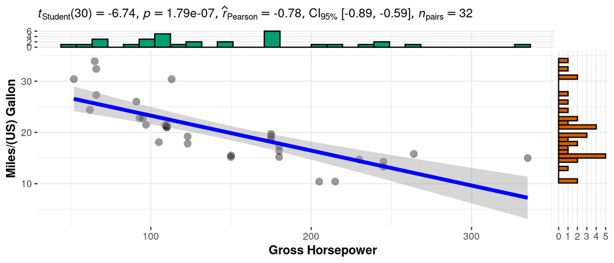

Figure 1: Scatter plot and test statistics.

```r
ggscatterstats(
  mtcars, hp, mpg,
  xlab = "Gross Horsepower",
  ylab = "Miles/(US) Gallon",
  type = "parametric"
) +
  labs(caption = NULL) # remove caption
```